# Practical Machine Learning: Prediction Assignment

Karen Mah

Thursday, 17 August 2015

## Introduction

Using devices such as Jawbone Up, Nike FuelBand, and Fitbit it is now possible to collect a large amount of data about personal activity relatively inexpensively. These type of devices are part of the quantified self movement â a group of enthusiasts who take measurements about themselves regularly to improve their health, to find patterns in their behavior, or because they are tech geeks. One thing that people regularly do is quantify how much of a particular activity they do, but they rarely quantify how well they do it.

In this project, we will use data from accelerometers on the belt, forearm, arm, and dumbell of 6 participants to predict the manner in which they did the exercise.

## Load the libraries

```r
library(caret)
library(rpart)
library(rpart.plot)
library(randomForest)
library(corrplot)
```

## Download the Data

```r
trainUrl <-"https://d396qusza40orc.cloudfront.net/predmachlearn/pml-training.csv"
testUrl <- "https://d396qusza40orc.cloudfront.net/predmachlearn/pml-testing.csv"
trainFile <- "./data/pml-training.csv"
testFile  <- "./data/pml-testing.csv"
if (!file.exists("./data")) {
  dir.create("./data")
}
if (!file.exists(trainFile)) {
  download.file(trainUrl, destfile=trainFile)
}
if (!file.exists(testFile)) {
  download.file(testUrl, destfile=testFile)
}
```

### Read and Clean the data

```r
trainData <- read.csv("./data/pml-training.csv", na.strings=c("", "NA", "NULL"))
testData <- read.csv("./data/pml-testing.csv", na.strings=c("", "NA", "NULL"))
```

### Clean the data by removing columns with NA

```r
trainData <- trainData[, colSums(is.na(trainData)) == 0]
testData <- testData[, colSums(is.na(testData)) == 0]
dim(trainData)
```

```
## [1] 19622    60
```

```r
dim(testData)
```

```
## [1] 20 60
```

The training data set contains 19622 observations and 60 variables, ad the testing data set contains 20 observations and 60 variables

The predictor variables will be belt, arm, dumbbell, and forearm variables since they do not have missing values.

We will now remove the variables that do not contribute to accelerometer measurements.

```r
classe <- trainData$classe
trainRemove <- grepl("^X|timestamp|window", names(trainData))
trainData <- trainData[, !trainRemove]
trainClean <- trainData[, sapply(trainData, is.numeric)]
trainClean$classe <- classe

testRemove <- grepl("^X|timestamp|window", names(testData))
testData <- testData[, !testRemove]
testClean <- testData[, sapply(testData, is.numeric)]

dim(trainClean)
```

```
## [1] 19622    53
```

```r
dim(testClean)
```

```
## [1] 20 53
```

Now, the cleaned training data set contains 19622 observations and 53 variables, while the testing data set contains 20 observations and 53 variables. The “classe” variable is still in the cleaned training set.

## Split data to training and testing for cross validation.

We will split the cleaned training set into a pure training data set (70%) and a testing(validation) data set (30%).

```r
set.seed(22519) # For reproducibile purpose
inTrain <- createDataPartition(trainClean$classe, p=0.70, list=F)
trainvData <- trainClean[inTrain, ]
testvData <- trainClean[-inTrain, ]
dim(trainvData)
```

```
## [1] 13737    53
```

```r
dim(testvData)
```

```
## [1] 5885   53
```

We have 13737 samples and 53 variables for training, and 5885 samples and 53 variables for testing.

## Data Modeling

```r
controlRf <- trainControl(method="cv", repeats = 5,allowParallel=TRUE)
modelRf <- train(classe ~ ., data=trainvData, method="rf", trControl=controlRf, ntree=250)
modelRf
```

```
## Random Forest
##
## 13737 samples
##    52 predictor
##     5 classes: 'A', 'B', 'C', 'D', 'E'
##
## No pre-processing
## Resampling: Cross-Validated (10 fold)
## Summary of sample sizes: 12363, 12364, 12362, 12362, 12363, 12363, ...
## Resampling results across tuning parameters:
##
##   mtry  Accuracy   Kappa      Accuracy SD  Kappa SD
##    2    0.9926475  0.9906987  0.002436570  0.003083315
##   27    0.9924294  0.9904230  0.002202486  0.002786935
##   52    0.9866062  0.9830549  0.003396763  0.004298868
##
## Accuracy was used to select the optimal model using  the largest value.
## The final value used for the model was mtry = 2.
```

Next, we will estimate the performance of the model on the testing (validation) data set.

```r
predictions <- predict(modelRf, testvData)
#predictions
confusionMatrix(predictions,testvData$classe)
```

```
## Confusion Matrix and Statistics
##
##           Reference
## Prediction    A    B    C    D    E
##          A 1673    3    0    0    0
##          B    1 1134    4    0    0
##          C    0    2 1021   25    0
##          D    0    0    1  939    5
##          E    0    0    0    0 1077
##
## Overall Statistics
##
##                Accuracy : 0.993
##                  95% CI : (0.9906, 0.995)
##     No Information Rate : 0.2845
##     P-Value [Acc > NIR] : < 2.2e-16
##
##                   Kappa : 0.9912
##  Mcnemar's Test P-Value : NA
##
## Statistics by Class:
##
##                      Class: A Class: B Class: C Class: D Class: E
## Sensitivity            0.9994   0.9956   0.9951   0.9741   0.9954
## Specificity            0.9993   0.9989   0.9944   0.9988   1.0000
## Pos Pred Value         0.9982   0.9956   0.9742   0.9937   1.0000
## Neg Pred Value         0.9998   0.9989   0.9990   0.9949   0.9990
## Prevalence             0.2845   0.1935   0.1743   0.1638   0.1839
## Detection Rate         0.2843   0.1927   0.1735   0.1596   0.1830
## Detection Prevalence   0.2848   0.1935   0.1781   0.1606   0.1830
## Balanced Accuracy      0.9993   0.9973   0.9948   0.9864   0.9977
```

```r
oose <- 1 - as.numeric(confusionMatrix(testvData$classe, predictions)$overall[1])
oose
```

```
## [1] 0.006966865
```

## Predicting for Test Data Set

Now, we apply the model to the original testing data set downloaded from the data source. We remove the `problem_id` column first.

```r
result <- predict(modelRf, testClean[, -length(names(testClean))])
result
```

```
##  [1] B A B A A E D B A A B C B A E E A B B B
## Levels: A B C D E
```

## Appendix: Figures

1. Correlation Matrix Visualization

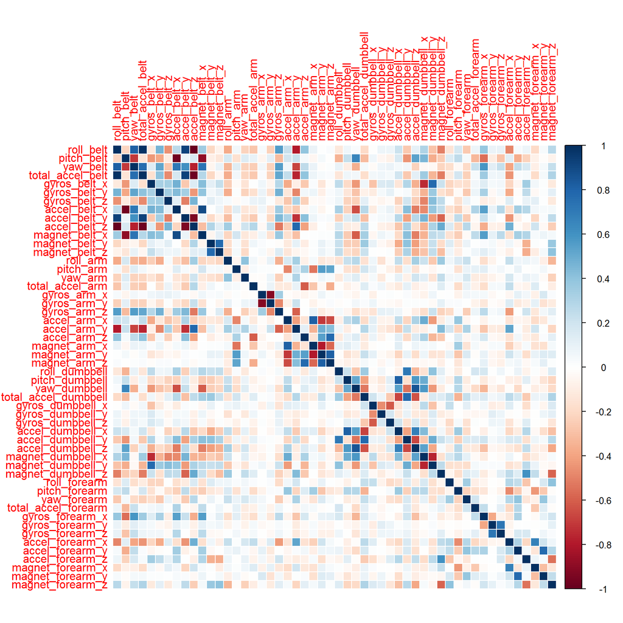

```r
corrPlot <- cor(trainvData[, -length(names(trainvData))])
corrplot(corrPlot, method="color")
```

2. Decision Tree Visualization

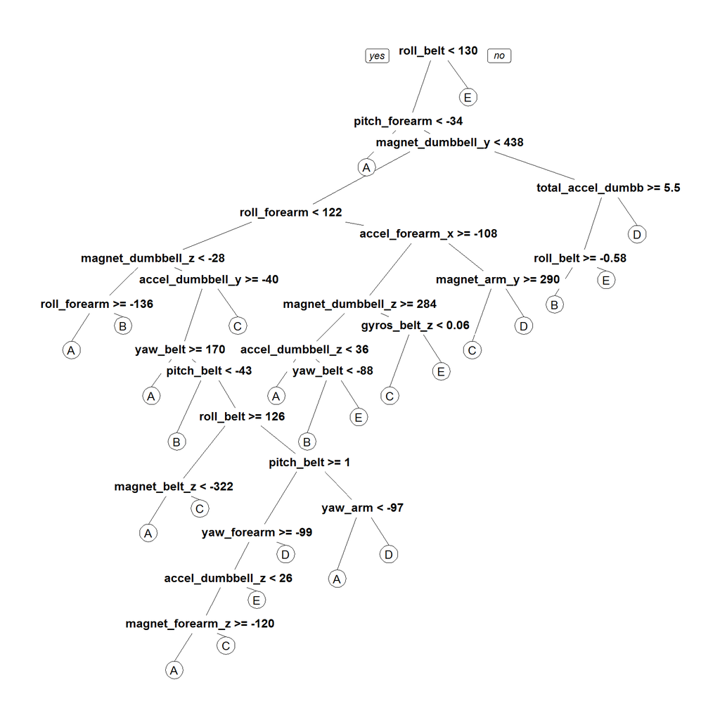

```r
treeModel <- rpart(classe ~ ., data=trainvData, method="class")
prp(treeModel) # fast plot
```